# Criminal Offense Trends: A Comprehensive Analysis of Demographic Variables in Offense Patterns

Niloy Saha

2024-12-15

## Title

### *‘Criminal Offense Trends: A Comprehensive Analysis of Demographic Variables in Offense Patterns’*

```r
library(dplyr)
library(tidyverse)
```

## Background

This research is driven by the need to understand potential systemic biases and inequities, offering data-driven insights that can inform policy reforms, promote fairness, and support more equitable practices within the justice system. The outcomes of this study contribute to the broader discourse on social justice, emphasizing the importance of evidence-based approaches in addressing disparities and fostering a transparent, equitable society. This analysis investigates the relationship between offense patterns, race, and age demographics to identify significant patterns and disparities within the criminal justice system.

## Dataset Description

```r
#Understanding the dataset


library(readr)
Crime_Data <- read_csv("C:/Users/niloy/OneDrive/Desktop/Group Files/Group Files/Crime Data.csv")
str(Crime_Data)
```

```
## spc_tbl_ [134,579 × 20] (S3: spec_tbl_df/tbl_df/tbl/data.frame)
##  $ SID Number             : num [1:134579] 671628 686567 770626 771601 786014 ...
##  $ TDCJ Number            : num [1:134579] 2394062 311644 449674 1491019 620145 ...
##  $ Name                   : chr [1:134579] "ONOFRE,JESSE TINAJERO" "PALACIOS,ROBERT LEONARD" "FLORES,ISABEL" "MOLETT,JOHN HENRY" ...
##  $ Current Facility       : chr [1:134579] "Jester III" "Telford" "Pack" "W. Scott" ...
##  $ Gender                 : chr [1:134579] "M" "M" "M" "M" ...
##  $ Race                   : chr [1:134579] "H" "H" "H" "B" ...
##  $ Age                    : num [1:134579] 89 86 87 82 86 86 85 83 86 83 ...
##  $ Projected Release      : chr [1:134579] "4/23/2026" "9/12/2028" "1/1/9999" "12/2/2037" ...
##  $ Maximum Sentence Date  : chr [1:134579] "4/23/2026" "5/12/2036" "1/1/9999" "12/2/2037" ...
##  $ Parole Eligibility Date: chr [1:134579] "4/22/2024" "4/15/2022" "9/2/2006" "12/2/2022" ...
##  $ Case Number            : chr [1:134579] "2019CR4680" "320670" "86CR-1234-B" "1144294" ...
##  $ County                 : chr [1:134579] "Bexar" "Harris" "Nueces" "Harris" ...
##  $ Offense Code           : num [1:134579] 36010001 22100000 9150000 12990002 11220000 ...
##  $ TDCJ Offense           : chr [1:134579] "INDEC W/CHILD CONTACT" "BURG HAB W/I SEXUAL ABUSE" "MURDER W/DEADLY WPN" "AGG ROBBERY W/DW" ...
##  $ Sentence Date          : chr [1:134579] "5/16/2022" "10/21/1980" "4/13/1987" "2/21/2008" ...
##  $ Offense Date           : chr [1:134579] "8/2/2016" "1/28/1980" "9/2/1986" "12/3/2007" ...
##  $ Sentence (Years)       : chr [1:134579] "4" "30" "Life" "30" ...
##  $ Last Parole Decision   : chr [1:134579] "Denied on 06/11/2024" "Denied on 05/01/2023" "Denied on 07/21/2021" "Denied on 01/24/2024" ...
##  $ Next Parole Review Date: chr [1:134579] "N/A" "Apr-26" "Jul-24" "Jan-25" ...
##  $ Parole Review Status   : chr [1:134579] "NOT IN REVIEW PROCESS" "NOT IN REVIEW PROCESS" "IN PAROLE REVIEW PROCESS" "NOT IN REVIEW PROCESS" ...
##  - attr(*, "spec")=
##   .. cols(
##   ..   `SID Number` = col_double(),
##   ..   `TDCJ Number` = col_double(),
##   ..   Name = col_character(),
##   ..   `Current Facility` = col_character(),
##   ..   Gender = col_character(),
##   ..   Race = col_character(),
##   ..   Age = col_double(),
##   ..   `Projected Release` = col_character(),
##   ..   `Maximum Sentence Date` = col_character(),
##   ..   `Parole Eligibility Date` = col_character(),
##   ..   `Case Number` = col_character(),
##   ..   County = col_character(),
##   ..   `Offense Code` = col_double(),
##   ..   `TDCJ Offense` = col_character(),
##   ..   `Sentence Date` = col_character(),
##   ..   `Offense Date` = col_character(),
##   ..   `Sentence (Years)` = col_character(),
##   ..   `Last Parole Decision` = col_character(),
##   ..   `Next Parole Review Date` = col_character(),
##   ..   `Parole Review Status` = col_character()
##   .. )
##  - attr(*, "problems")=<externalptr>
```

```r
dim(Crime_Data)
```

```
## [1] 134579     20
```

**Source:**

The dataset is provided by the **Texas Department of Criminal Justice (TDCJ)**, titled *“High-Value Dataset, July 2024.” (link :* https://data.texas.gov/dataset/High-Value-Dataset-July-2024/qz8r-du54/about_data%5D)

- Rights: As the dataset is publicly available through governmental portal, there is no restrictions in sharing and usage.
- Limitations: The dataset only covers offenses for a specific period. It also pertains to only offenders under the jurisdiction of Texas Department of Justice. Certain racial groups or offense types may have small sample sizes, impacting the robustness of statistical analysis.The categorization of offenses might be broad or subjective, which could influence the interpretation of results.

**Size:**

Number of Rows: 134579

Number of Columns: 20

**key Features:**

The dataset contains the following key attributes:

- Race: Categorical variable indicating the racial group of the offender (e.g., White, Black, Hispanic).
- Age: Numeric variable representing the age of the offender.
- TDCJ Offense: Detailed description of the offense committed by the offender.
- Parole Decision: Outcome of parole hearings (e.g., Approved, Denied).
- Gender: Categorical variable representing the gender of the offender.

Other Demographic Details: Additional information such as sentence date, County, and sentence length.

#### **Purpose of the Dataset:**

The dataset is intended for analyzing trends and disparities in the criminal justice system based on demograhic and offense patterns.

## Analysis

### *Part 1 : Data Cleaning*

```r
#Understanding the dataset


Crime_Data <- read_csv("C:/Users/niloy/OneDrive/Desktop/Group Files/Group Files/Crime Data.csv")
str(Crime_Data)
```

```
## spc_tbl_ [134,579 × 20] (S3: spec_tbl_df/tbl_df/tbl/data.frame)
##  $ SID Number             : num [1:134579] 671628 686567 770626 771601 786014 ...
##  $ TDCJ Number            : num [1:134579] 2394062 311644 449674 1491019 620145 ...
##  $ Name                   : chr [1:134579] "ONOFRE,JESSE TINAJERO" "PALACIOS,ROBERT LEONARD" "FLORES,ISABEL" "MOLETT,JOHN HENRY" ...
##  $ Current Facility       : chr [1:134579] "Jester III" "Telford" "Pack" "W. Scott" ...
##  $ Gender                 : chr [1:134579] "M" "M" "M" "M" ...
##  $ Race                   : chr [1:134579] "H" "H" "H" "B" ...
##  $ Age                    : num [1:134579] 89 86 87 82 86 86 85 83 86 83 ...
##  $ Projected Release      : chr [1:134579] "4/23/2026" "9/12/2028" "1/1/9999" "12/2/2037" ...
##  $ Maximum Sentence Date  : chr [1:134579] "4/23/2026" "5/12/2036" "1/1/9999" "12/2/2037" ...
##  $ Parole Eligibility Date: chr [1:134579] "4/22/2024" "4/15/2022" "9/2/2006" "12/2/2022" ...
##  $ Case Number            : chr [1:134579] "2019CR4680" "320670" "86CR-1234-B" "1144294" ...
##  $ County                 : chr [1:134579] "Bexar" "Harris" "Nueces" "Harris" ...
##  $ Offense Code           : num [1:134579] 36010001 22100000 9150000 12990002 11220000 ...
##  $ TDCJ Offense           : chr [1:134579] "INDEC W/CHILD CONTACT" "BURG HAB W/I SEXUAL ABUSE" "MURDER W/DEADLY WPN" "AGG ROBBERY W/DW" ...
##  $ Sentence Date          : chr [1:134579] "5/16/2022" "10/21/1980" "4/13/1987" "2/21/2008" ...
##  $ Offense Date           : chr [1:134579] "8/2/2016" "1/28/1980" "9/2/1986" "12/3/2007" ...
##  $ Sentence (Years)       : chr [1:134579] "4" "30" "Life" "30" ...
##  $ Last Parole Decision   : chr [1:134579] "Denied on 06/11/2024" "Denied on 05/01/2023" "Denied on 07/21/2021" "Denied on 01/24/2024" ...
##  $ Next Parole Review Date: chr [1:134579] "N/A" "Apr-26" "Jul-24" "Jan-25" ...
##  $ Parole Review Status   : chr [1:134579] "NOT IN REVIEW PROCESS" "NOT IN REVIEW PROCESS" "IN PAROLE REVIEW PROCESS" "NOT IN REVIEW PROCESS" ...
##  - attr(*, "spec")=
##   .. cols(
##   ..   `SID Number` = col_double(),
##   ..   `TDCJ Number` = col_double(),
##   ..   Name = col_character(),
##   ..   `Current Facility` = col_character(),
##   ..   Gender = col_character(),
##   ..   Race = col_character(),
##   ..   Age = col_double(),
##   ..   `Projected Release` = col_character(),
##   ..   `Maximum Sentence Date` = col_character(),
##   ..   `Parole Eligibility Date` = col_character(),
##   ..   `Case Number` = col_character(),
##   ..   County = col_character(),
##   ..   `Offense Code` = col_double(),
##   ..   `TDCJ Offense` = col_character(),
##   ..   `Sentence Date` = col_character(),
##   ..   `Offense Date` = col_character(),
##   ..   `Sentence (Years)` = col_character(),
##   ..   `Last Parole Decision` = col_character(),
##   ..   `Next Parole Review Date` = col_character(),
##   ..   `Parole Review Status` = col_character()
##   .. )
##  - attr(*, "problems")=<externalptr>
```

```r
dim(Crime_Data)
```

```
## [1] 134579     20
```

```r
#checking for need of cleaning
colSums(is.na(Crime_Data)|Crime_Data == "")
```

```
##              SID Number             TDCJ Number                    Name
##                       0                       0                       0
##        Current Facility                  Gender                    Race
##                       0                       0                       0
##                     Age       Projected Release   Maximum Sentence Date
##                       0                      10                     574
## Parole Eligibility Date             Case Number                  County
##                   11973                      56                       0
##            Offense Code            TDCJ Offense           Sentence Date
##                       0                      52                    2861
##            Offense Date        Sentence (Years)    Last Parole Decision
##                       0                      59                   11622
## Next Parole Review Date    Parole Review Status
##                   11622                   11622
```

```r
#cleaning the data

#removing NA values
cleaned_crime <- Crime_Data %>%
  na.omit()
#removing blank values
cleaned_crime <- cleaned_crime[apply(cleaned_crime != "" , 1 , all ), ]




#Checking the number of blanks and NAs after cleaning to confirm
dim(cleaned_crime)
```

```
## [1] 119264     20
```

```r
colSums(is.na(cleaned_crime)|cleaned_crime == "")
```

```
##              SID Number             TDCJ Number                    Name
##                       0                       0                       0
##        Current Facility                  Gender                    Race
##                       0                       0                       0
##                     Age       Projected Release   Maximum Sentence Date
##                       0                       0                       0
## Parole Eligibility Date             Case Number                  County
##                       0                       0                       0
##            Offense Code            TDCJ Offense           Sentence Date
##                       0                       0                       0
##            Offense Date        Sentence (Years)    Last Parole Decision
##                       0                       0                       0
## Next Parole Review Date    Parole Review Status
##                       0                       0
```

```r
#updating column names
names(cleaned_crime) <- tolower(names(cleaned_crime))
names(cleaned_crime)
```

```
##  [1] "sid number"              "tdcj number"
##  [3] "name"                    "current facility"
##  [5] "gender"                  "race"
##  [7] "age"                     "projected release"
##  [9] "maximum sentence date"   "parole eligibility date"
## [11] "case number"             "county"
## [13] "offense code"            "tdcj offense"
## [15] "sentence date"           "offense date"
## [17] "sentence (years)"        "last parole decision"
## [19] "next parole review date" "parole review status"
```

```r
View(cleaned_crime)
```

**Comment:** In this first step, we have initiated the cleaning procedure over the dataset as it has many rows with NA and blank values which can be observed through the code run.After cleaning the dataset, we have called it “cleaned crime” and checked if the dataset is fully cleaned of blank rows and NA values. As all columns are cleaned of these values, We updated the column names also to analyse effectively. The “final_crime_Date” is the final dataset after cleaning.

### *Part 2: Data Preparation*

```r
#Selection of relevant columns

final_crime_data <- cleaned_crime %>%
  select(1,3,5,6,7,14,17,18,19, 20)
colnames((final_crime_data))
```

```
##  [1] "sid number"              "name"
##  [3] "gender"                  "race"
##  [5] "age"                     "tdcj offense"
##  [7] "sentence (years)"        "last parole decision"
##  [9] "next parole review date" "parole review status"
```

```r
#Unique offenses to list for categorisation

unique_offenses <-  unique(final_crime_data$`tdcj offense`)





#Function for categorizing offenses

categorise_function <- function(offense) {
  if (grepl("MURDER|ASSAULT|ROBBERY|HOMICIDE|KIDNAPPING", offense, ignore.case = TRUE)) {
    return("violent crimes")
  } else if(grepl("BURGLARY|THEFT|ARSON",offense, ignore.case = TRUE)) {
  return("property crimes")
  }  else if (grepl("DRUG|SUBSTANCE",offense, ignore.case = TRUE)){
  return("drug offenses")
  }   else if(grepl("SEXUAL|INDECENCY", offense, ignore.case = TRUE)) {
    return("sexual crimes")
  }   else if (grepl("WEAPON|FIREARM", offense, ignore.case = TRUE)) {
    return("Weapon Crimes")
  }   else {
    return("other crimes")
  }
}



#Creating the new column as "Offense Category" by function

final_crime_data <- final_crime_data %>%
  mutate(Offense_Category = sapply(`tdcj offense`, categorise_function))




#Count NA and blank values after new column added

colSums(is.na(final_crime_data)|final_crime_data == "")
```

```
##              sid number                    name                  gender
##                       0                       0                       0
##                    race                     age            tdcj offense
##                       0                       0                       0
##        sentence (years)    last parole decision next parole review date
##                       0                       0                       0
##    parole review status        Offense_Category
##                       0                       0
```

```r
head(final_crime_data)
```

```
## # A tibble: 6 × 11
##   `sid number` name         gender race    age `tdcj offense` `sentence (years)`
##          <dbl> <chr>        <chr>  <chr> <dbl> <chr>          <chr>
## 1       671628 ONOFRE,JESS… M      H        89 INDEC W/CHILD… 4
## 2       686567 PALACIOS,RO… M      H        86 BURG HAB W/I … 30
## 3       770626 FLORES,ISAB… M      H        87 MURDER W/DEAD… Life
## 4       771601 MOLETT,JOHN… M      B        82 AGG ROBBERY W… 30
## 5       786014 GLENDINNING… M      W        86 AGG SEX ASLT … Life
## 6       852859 PALERMO,THO… M      W        85 MURDER         70
## # ℹ 4 more variables: `last parole decision` <chr>,
## #   `next parole review date` <chr>, `parole review status` <chr>,
## #   Offense_Category <chr>
```

**Comment:** After cleaning the dataset, we went on to prepare the dataset for analysis. we have added a new column named “Offense catgory” to categorise similar offenses and make our analysis more understandable on a general perspective. And we have checked again for blank rows and rows with ‘NA’ values in the new column. Finally, We can now work on this cleaned and prepared dataset for analysis and interpretation.

### *Part 3: Descriptive Analysis*

```r
#converting columns into factors for summary
final_crime_data$race <- as.factor(final_crime_data$race)
final_crime_data$Offense_Category <- as.factor(final_crime_data$Offense_Category)



#Summary of crime related statistic of convicts by Race
count_of_offenses <- final_crime_data %>%
  group_by( race , Offense_Category) %>%
  summarise(count = n(), .groups = "drop")
print(count_of_offenses)
```

```
## # A tibble: 34 × 3
##    race  Offense_Category count
##    <fct> <fct>            <int>
##  1 A     other crimes       280
##  2 A     property crimes      8
##  3 A     sexual crimes       19
##  4 A     violent crimes     163
##  5 A     Weapon Crimes       11
##  6 B     drug offenses       13
##  7 B     other crimes     21685
##  8 B     property crimes    862
##  9 B     sexual crimes     1188
## 10 B     violent crimes   15020
## # ℹ 24 more rows
```

```r
#Summary of age related stistics for convicts
convict_age_summary <- final_crime_data %>%
group_by(race, Offense_Category)%>%
summarise(
mean_age = mean(age, na.rm =TRUE),
median_age = median(age, na.rm=TRUE),
min_age = min(age, na.rm = TRUE),
max_age = max(age, na.rm=TRUE),
range_age = max_age - min_age
)
print(convict_age_summary)
```

```
## # A tibble: 34 × 7
## # Groups:   race [7]
##    race  Offense_Category mean_age median_age min_age max_age range_age
##    <fct> <fct>               <dbl>      <dbl>   <dbl>   <dbl>     <dbl>
##  1 A     other crimes         42.1       41        20      77        57
##  2 A     property crimes      46.4       46.5      26      70        44
##  3 A     sexual crimes        49         51        32      77        45
##  4 A     violent crimes       42.2       41        19      85        66
##  5 A     Weapon Crimes        37.3       37        26      47        21
##  6 B     drug offenses        45.7       44        28      62        34
##  7 B     other crimes         40.9       39        17      85        68
##  8 B     property crimes      44.3       44        18      73        55
##  9 B     sexual crimes        44.9       44        18      84        66
## 10 B     violent crimes       39.0       37        17      91        74
## # ℹ 24 more rows
```

### *Part 4: Visualisation*

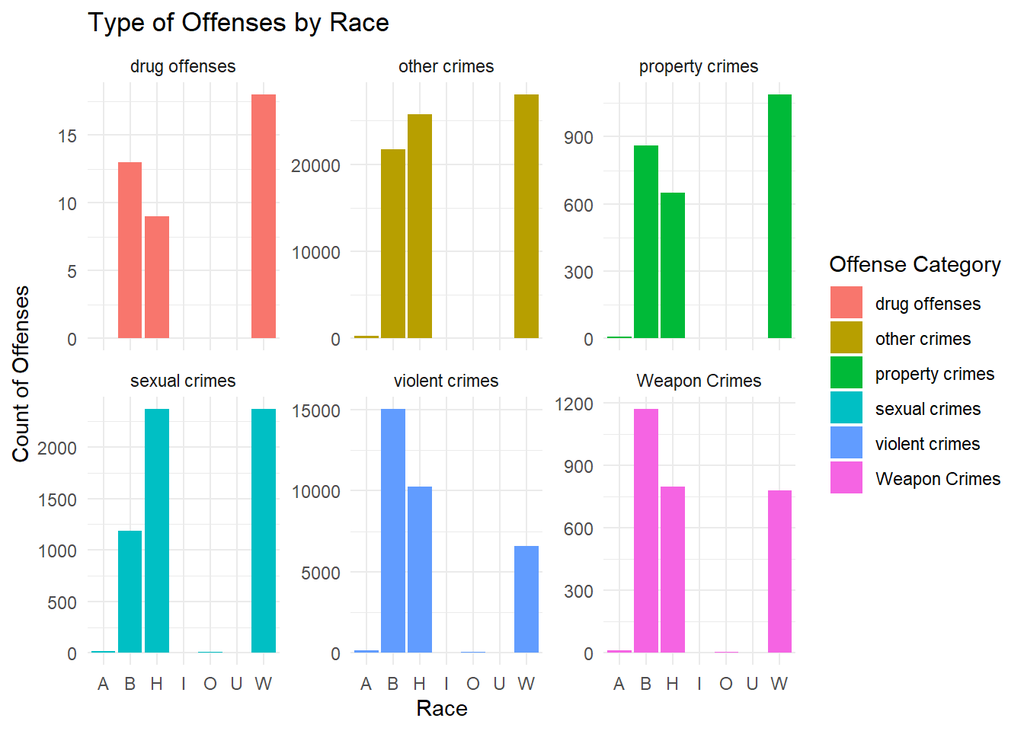

```r
#Bar Plot- Visualisation of the relationship between race and offence type

ggplot(count_of_offenses, aes(x = race, y = count, fill = Offense_Category)) +
  geom_col(position = "dodge") +
  labs(
    title = "Type of Offenses by Race",
    x = "Race",
    y = "Count of Offenses",
    fill = "Offense Category"
  ) +
  theme_minimal()  + facet_wrap(~ Offense_Category, scales = "free_y")
```

**Comment:** From the graph, we can see that Blacks, Hispanics and Whites dominate the chart data in terms of offense types. For example, drug offenses are mostly carried by the Whites and Blacks but the sexual crimes are committed by Hispanics in high number. In terms of violent crimes, Blacks are the most reported convicts much higher than both Whites and Hispanics.

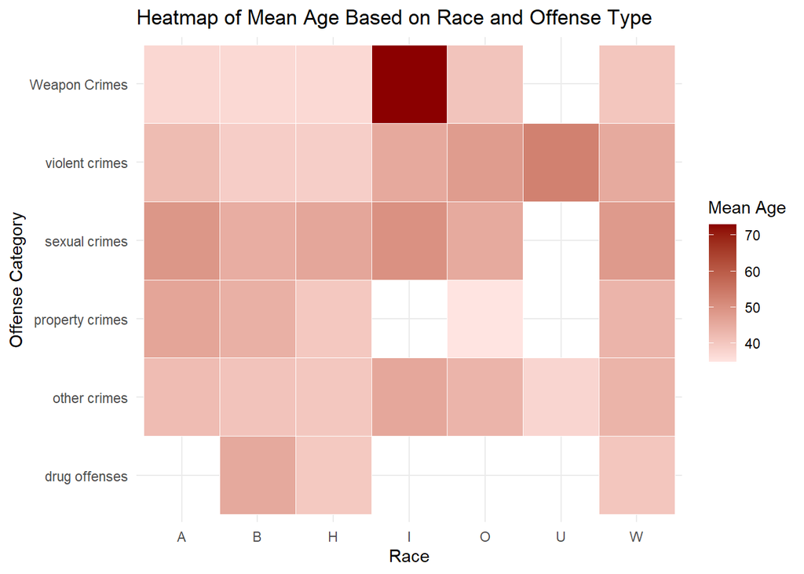

```r
#Heatmap - Visualisation of the relationship among age, race and offense type

ggplot(convict_age_summary, aes(x = race, y = Offense_Category, fill = mean_age)) +
  geom_tile(color = "white") +
  scale_fill_gradient(low = "mistyrose", high = "darkred") +
  labs(title = "Heatmap of Mean Age Based on Race and Offense Type", x = "Race", y = "Offense Category", fill = "Mean Age") +
  theme_minimal()
```

**Comment:** From the heatmap, we can see that ages of most convicts regardless of race fall between 40-60 bracket. But offenders committing weapon crimes tend to be younger, while those involved in sexual crimes tend to be older across most racial groups

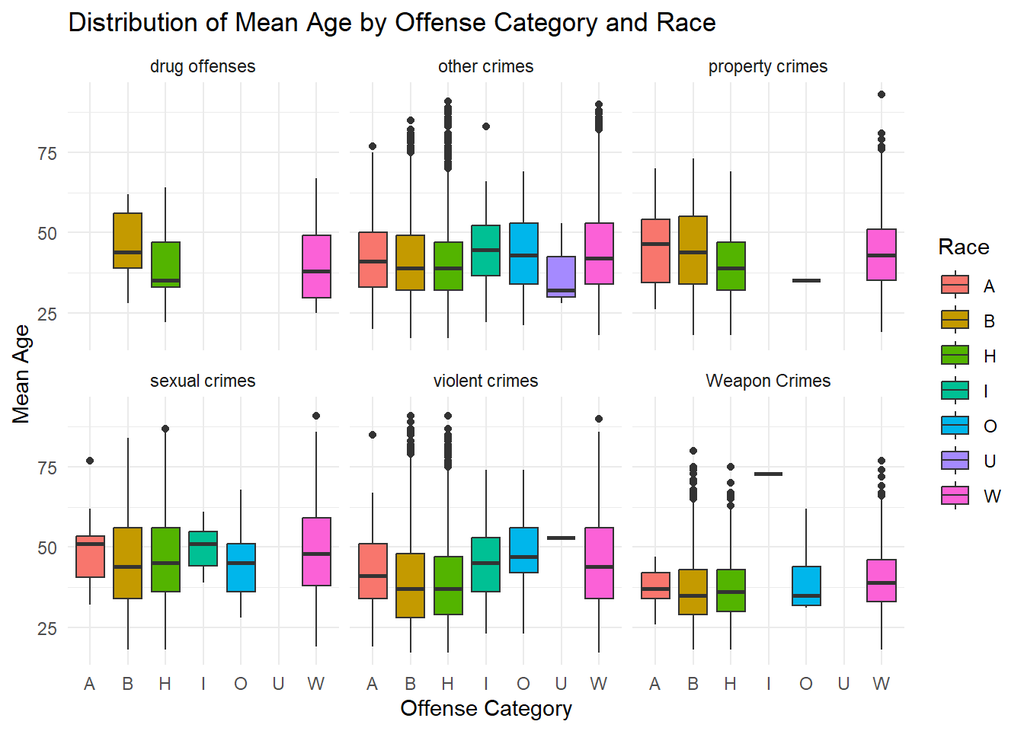

```r
#Boxplot - visualisation of the relationship of mean age with offense patterns and race


ggplot(final_crime_data, aes(x = race, y = age, fill = race)) +
  geom_boxplot() +
  labs(title = "Distribution of Mean Age by Offense Category and Race", x = "Offense Category", y = "Mean Age", fill = "Race") +
  theme_minimal() + facet_wrap(~Offense_Category)
```

### *Part 5: Hypothesis Testing*

Null Hypothesis : The mean age does not differ across race groups

Alternate Hypothesis: The mean age differs significantly across race groups

```r
#Hypothesis Testing

#ANOVA_test
anova_result <- aov(age ~ race, data = final_crime_data)
anova_summary <- summary(anova_result)

#checking p value
p_value <- anova_summary[[1]][1,"Pr(>F)"]
p_value
```

```
## [1] 0
```

```r
#Hypothesis Results
if (p_value < 0.05) {
  cat("There is a significant difference in mean age across races.\n")
} else {
  cat("There is no significant difference in mean age across races.\n")
}
```

```
## There is a significant difference in mean age across races.
```

```r
#Detecting the races between which age difers
Pairwise_race <- TukeyHSD(anova_result)
print(Pairwise_race)
```

```
##   Tukey multiple comparisons of means
##     95% family-wise confidence level
##
## Fit: aov(formula = age ~ race, data = final_crime_data)
##
## $race
##           diff          lwr        upr     p adj
## B-A -2.1159239  -3.80520547 -0.4266424 0.0041641
## H-A -2.2498110  -3.93912973 -0.5604923 0.0016710
## I-A  4.5192308  -0.85683222  9.8952938 0.1670660
## O-A  3.5609628   0.09021095  7.0317147 0.0399492
## U-A -0.8846154 -19.37488694 17.6056562 0.9999993
## W-A  1.8067825   0.11721975  3.4963453 0.0270164
## H-B -0.1338871  -0.39474114  0.1269669 0.7369860
## I-B  6.6351547   1.52474370 11.7455657 0.0024746
## O-B  5.6768868   2.63380182  8.7199717 0.0000008
## U-B  1.2313085 -17.18347872 19.6460958 0.9999951
## W-B  3.9227064   3.66027643  4.1851364 0.0000000
## I-H  6.7690418   1.65861854 11.8794651 0.0018208
## O-H  5.8107739   2.76766833  8.8538794 0.0000004
## U-H  1.3651956 -17.04959500 19.7799863 0.9999910
## W-H  4.0565936   3.79392462  4.3192625 0.0000000
## O-I -0.9582679  -6.90038430  4.9838485 0.9991465
## U-I -5.4038462 -24.51281709 13.7051248 0.9814739
## W-I -2.7124482  -7.82295219  2.3980557 0.7049255
## U-O -4.4455782 -23.10829068 14.2171342 0.9925038
## W-O -1.7541803  -4.79742137  1.2890607 0.6164204
## W-U  2.6913979 -15.72341514 21.1062109 0.9995148
```

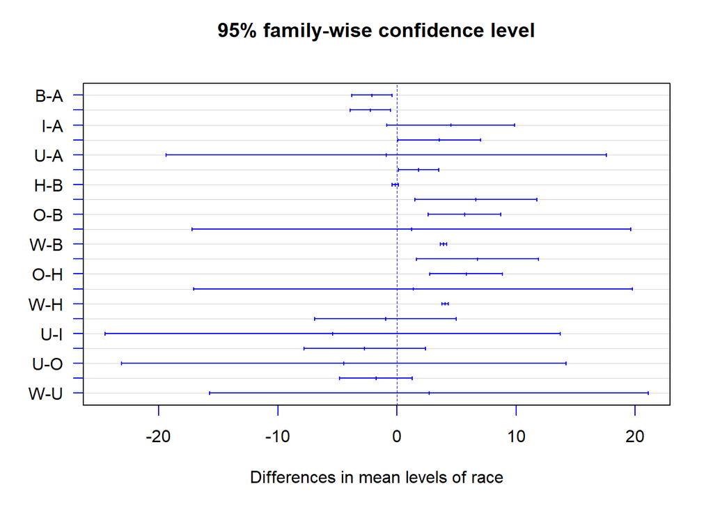

```r
plot(Pairwise_race,las = 1, col = "blue")
```

**Comment:** As we can see, the hypothesis is that there is no significant difference in mean age across race groups. But after doing the hypothesis testing, we can see that the p value is less than .05, meaning that there is significant difference in mean age across race groups. To analyse, the race groups with most differences in mean age, we have also conducted Tukey’s HSD test. Comparisons where the **confidence interval does not cross 0** indicate a **significant difference** in mean ages between the two race groups. For example, Blacks and Asians convicts have signficant difference in mean age.